# Model building

2023-11-04

## Rでモデルを作る技法

実データでモデルを使ったデータ理解のワークフローを追う

### 準備

```r
library(tidyverse)
library(modelr)
options(na.action = na.warn)

library(nycflights13)
library(lubridate)
```

## 24.1 Introduction

- 私たちは対象についてのふわっとした知識を持っている
- その知識を形式的で定量的なモデルへと変換する
- そのモデルを使って以下が可能になる
  - 我々の知識を使った予測
  - データに潜む新たな知識の発見

### 別のアプローチ（機械学習）

- 予測精度をひたすら高める
- データが複雑すぎる場合はしゃーない？
- ブラックボックスになりがち
  - うまくいく理由も条件も分からない
  - 将来大きな変化があっても機能するだろうか？

## 24.2 なぜ低品質なダイヤモンドの方が高価なのか？

ダイヤモンドの品質は次の4Cで決まる(はず)

- carat: [カラット](https://www.brilliance.co.jp/engagement/select/carat.html)ダイヤモンドの重さ。1 ct=0.2 g
- cut: [カット](https://www.brilliance.co.jp/engagement/select/cut.html)（形状、仕上がり）
- color: [色](https://www.brilliance.co.jp/engagement/select/color.html)。一般的には色が無い方が偉い。Dが最も無色でZに向かって色有り
- clarity: [透明度](https://www.brilliance.co.jp/engagement/select/clarity.html)。I1, SI2, SI1, VS2, VS1, VVS2, VVS1, IFの順に良い

## cutが悪い方が高価？

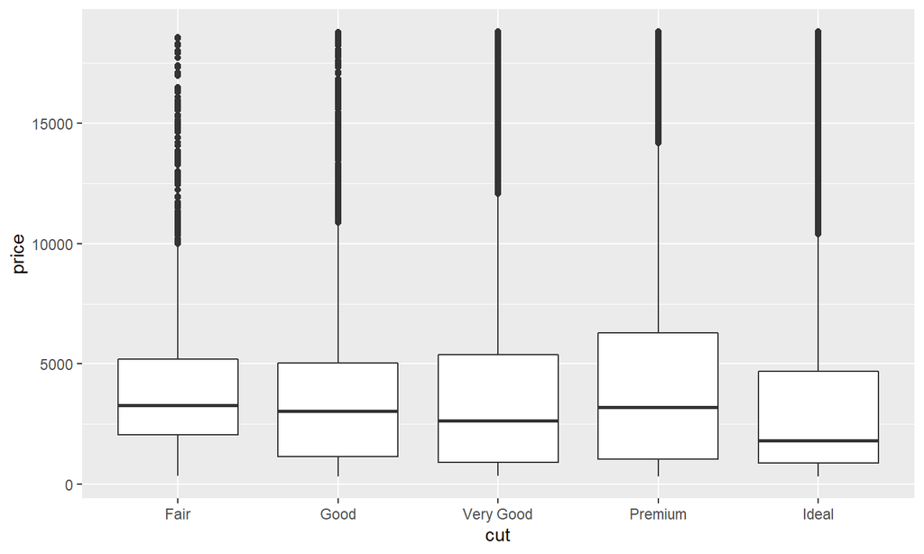

```r
ggplot(diamonds, aes(cut, price)) + geom_boxplot()
```

## colorが悪い方が高価？

colorはDが一番良くて、Jが一番悪い

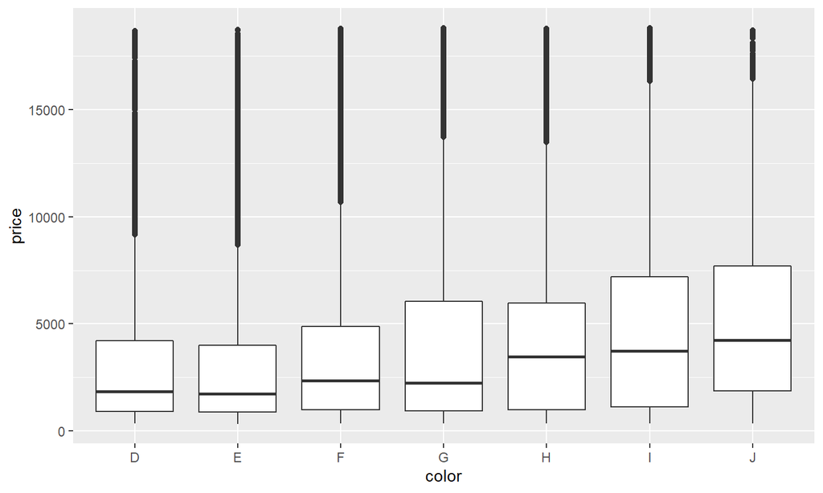

```r
ggplot(diamonds, aes(color, price)) + geom_boxplot()
```

## clarityが悪い方が高価？

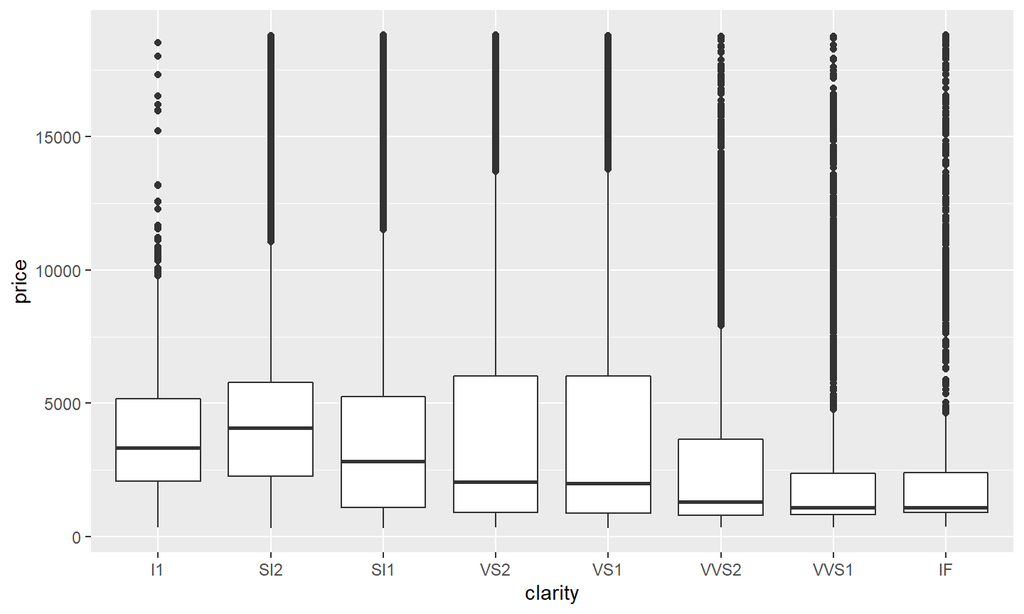

```r
ggplot(diamonds, aes(clarity, price)) + geom_boxplot()
```

## 24.2.1 価格とカラット

交絡因子カラット

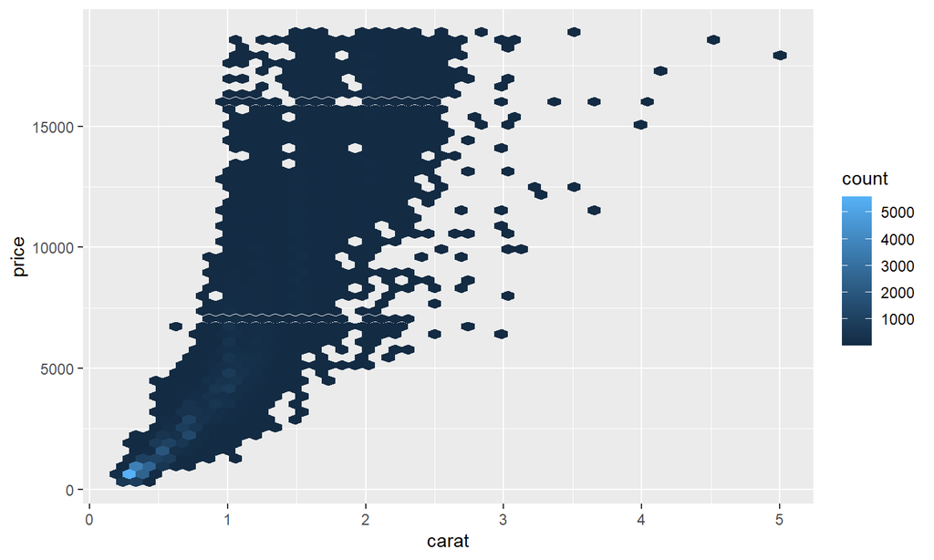

```r
ggplot(diamonds, aes(carat, price)) + geom_hex(bins = 50)
```

## 方針

- モデルを使って価格を決める最大の因子 `carat` の影響を除去する
- `carat` の影響を除去したときに他の因子が価格にどう影響するかを調べる

### 準備

```r
diamonds2 <- diamonds %>%
  filter(carat <= 2.5) %>%  #低カラットに絞り込む(全体の99.7%)
  mutate(lprice = log2(price), lcarat = log2(carat)) #対数変換
```

## 可視化

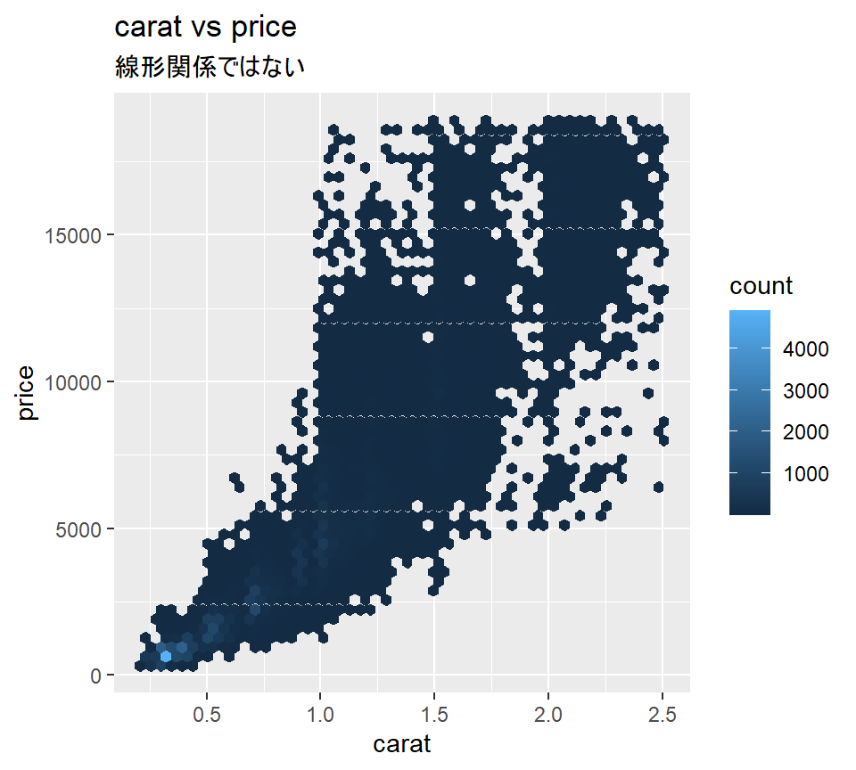

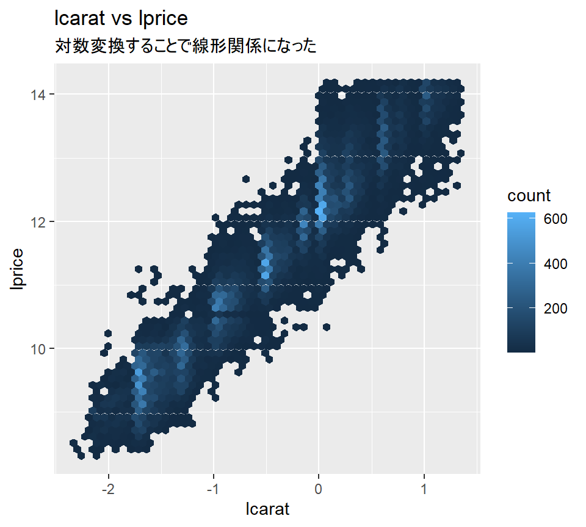

## モデル分析

```r
mod_diamond <- lm(lprice ~ lcarat, data = diamonds2)
summary(mod_diamond)
```

```
##
## Call:
## lm(formula = lprice ~ lcarat, data = diamonds2)
##
## Residuals:
##      Min       1Q   Median       3Q      Max
## -1.96407 -0.24549 -0.00844  0.23930  1.93486
##
## Coefficients:
##              Estimate Std. Error t value Pr(>|t|)
## (Intercept) 12.193863   0.001969  6194.5   <2e-16 ***
## lcarat       1.681371   0.001936   868.5   <2e-16 ***
## ---
## Signif. codes:  0 '***' 0.001 '**' 0.01 '*' 0.05 '.' 0.1 ' ' 1
##
## Residual standard error: 0.3767 on 53812 degrees of freedom
## Multiple R-squared:  0.9334, Adjusted R-squared:  0.9334
## F-statistic: 7.542e+05 on 1 and 53812 DF,  p-value: < 2.2e-16
```

## モデル可視化

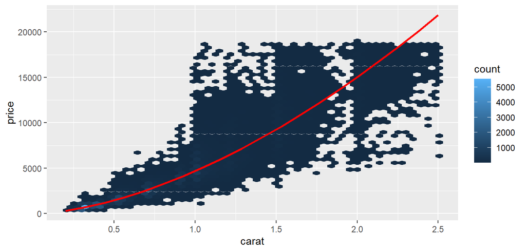

```r
grid <- diamonds2 %>%  data_grid(carat = seq_range(carat, 20)) %>%
  mutate(lcarat = log2(carat)) %>%
  add_predictions(mod_diamond, "lprice") %>%  mutate(price = 2 ^ lprice)
ggplot(diamonds2, aes(carat, price)) +
  geom_hex(bins = 50) +  geom_line(data = grid, colour = "red", size = 1)
```

## 残差の可視化

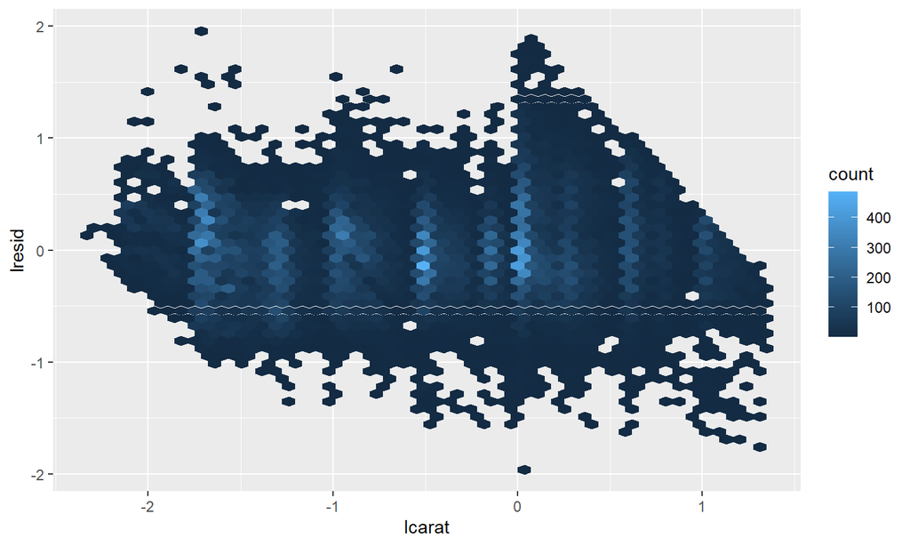

```r
diamonds2 <- diamonds2 %>%  add_residuals(mod_diamond, "lresid")
ggplot(diamonds2, aes(lcarat, lresid)) +  geom_hex(bins = 50)
```

## cut vs 残差

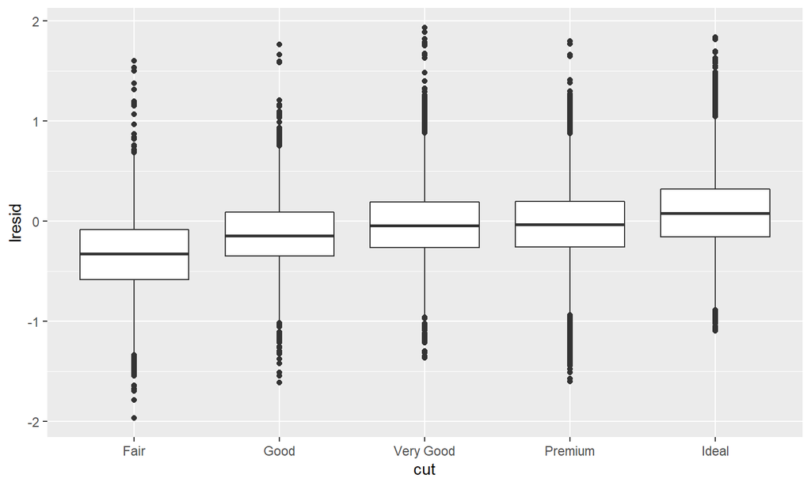

```r
ggplot(diamonds2, aes(cut, lresid)) + geom_boxplot()
```

## color vs 残差

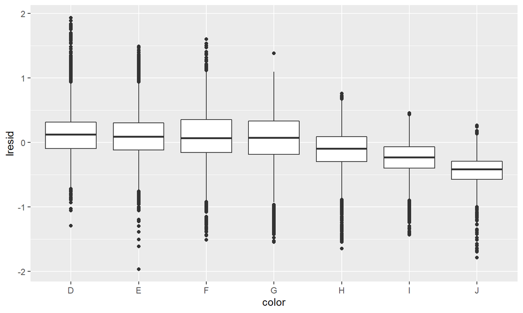

```r
ggplot(diamonds2, aes(color, lresid)) + geom_boxplot()
```

## clarity vs 残差

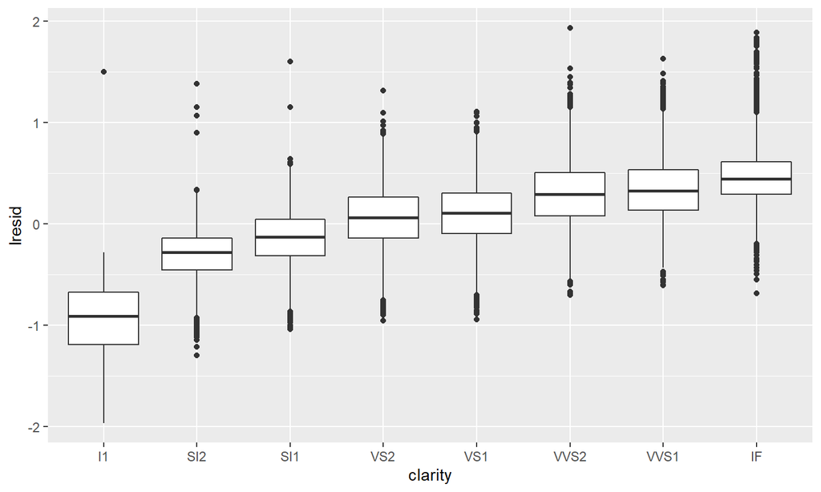

```r
ggplot(diamonds2, aes(clarity, lresid)) + geom_boxplot()
```

## 24.2.2 より複雑なモデル

```r
mod_diamond2 <- lm(lprice ~ lcarat + color + cut + clarity, data = diamonds2)
summary(mod_diamond2)$coefficients
```

```
##                 Estimate  Std. Error      t value      Pr(>|t|)
## (Intercept) 12.206977965 0.001692638 7211.8056242  0.000000e+00
## lcarat       1.886239132 0.001124227 1677.8093006  0.000000e+00
## color.L     -0.633998257 0.002909964 -217.8715403  0.000000e+00
## color.Q     -0.137579548 0.002676159  -51.4093408  0.000000e+00
## color.C     -0.022071806 0.002502875   -8.8185817  1.193052e-18
## color^4      0.016569789 0.002297151    7.2131908  5.537381e-13
## color^5     -0.002828016 0.002169283   -1.3036640  1.923537e-01
## color^6      0.003533157 0.001970679    1.7928629  7.300046e-02
## cut.L        0.173865808 0.003385948   51.3492207  0.000000e+00
## cut.Q       -0.050345645 0.002979518  -16.8972432  6.894817e-64
## cut.C        0.019128669 0.002582593    7.4067691  1.313014e-13
## cut^4       -0.002410361 0.002066319   -1.1664995  2.434177e-01
## clarity.L    1.308155179 0.005178801  252.5980787  0.000000e+00
## clarity.Q   -0.334089571 0.004838561  -69.0473035  0.000000e+00
## clarity.C    0.178422700 0.004140442   43.0926673  0.000000e+00
## clarity^4   -0.088059278 0.003298473  -26.6969813 5.332347e-156
## clarity^5    0.035884717 0.002680109   13.3892766  8.121885e-41
## clarity^6   -0.001371424 0.002327080   -0.5893324  5.556408e-01
## clarity^7    0.048221081 0.002050947   23.5116140 1.278000e-121
```

## モデル予測(cutの周辺)

```r
grid <- diamonds2 %>%
  data_grid(cut, .model = mod_diamond2) %>%
  add_predictions(mod_diamond2)
grid
```

```
## # A tibble: 5 × 5
##   cut        lcarat color clarity  pred
##   <ord>       <dbl> <chr> <chr>   <dbl>
## 1 Fair      -0.5146 G     VS2     11.21
## 2 Good      -0.5146 G     VS2     11.32
## 3 Very Good -0.5146 G     VS2     11.37
## 4 Premium   -0.5146 G     VS2     11.41
## 5 Ideal     -0.5146 G     VS2     11.44
```

\(2^{0.1}\sim1.07\)

## 残差の可視化

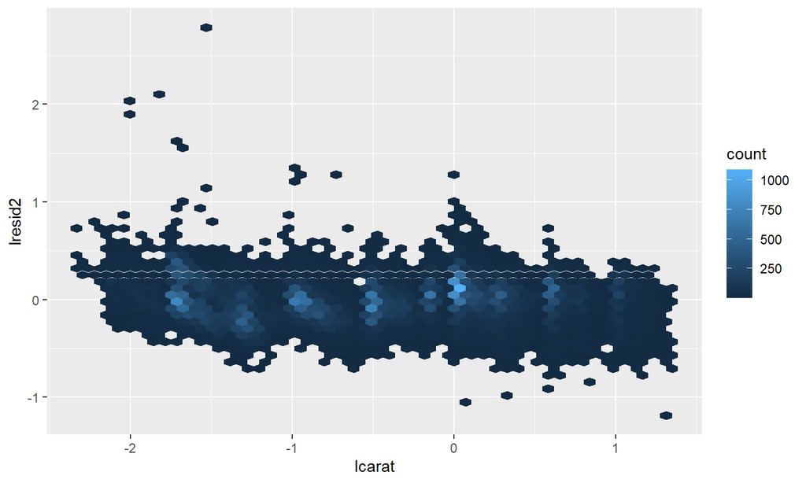

```r
diamonds2 <- diamonds2 %>%  add_residuals(mod_diamond2, "lresid2")
ggplot(diamonds2, aes(lcarat, lresid2)) +  geom_hex(bins = 50)
```

## 24.2.3 Exercise

## 24.3 一日のフライト数に影響を与える要素は何か？